# EDA

yarosalv khomko

2026-01-23

Wykorystane biblioteki

```r
library(tidyverse)
```

#### Wstęp

Celem niniejszej eksploracyjnej analizy danych jest zbadanie zbioru danych dotyczącego gier szachowych pochodzących z serwisu Lichess, sformułowanie interesujących pytań badawczych oraz wyciągnięcie na ich podstawie wniosków.

#### Wyczytanie i przegląd danych

Na początku wczytamy dane i wstępnie przyjrzymy się ich strukturze oraz zawartości.

```r
chess <- read.csv("games.csv")
head(chess, 5)
```

```
##         id rated  created_at last_move_at turns victory_status winner
## 1 TZJHLljE FALSE 1.50421e+12  1.50421e+12    13      outoftime  white
## 2 l1NXvwaE  TRUE 1.50413e+12  1.50413e+12    16         resign  black
## 3 mIICvQHh  TRUE 1.50413e+12  1.50413e+12    61           mate  white
## 4 kWKvrqYL  TRUE 1.50411e+12  1.50411e+12    61           mate  white
## 5 9tXo1AUZ  TRUE 1.50403e+12  1.50403e+12    95           mate  white
##   increment_code      white_id white_rating     black_id black_rating
## 1           15+2      bourgris         1500         a-00         1191
## 2           5+10          a-00         1322    skinnerua         1261
## 3           5+10        ischia         1496         a-00         1500
## 4           20+0 daniamurashov         1439 adivanov2009         1454
## 5           30+3     nik221107         1523 adivanov2009         1469
##                                                                                                                                                                                                                                                                                                          …
## 1                                                                                                                                                                                                                                                                                                        …
## 2                                                                                                                                                                                                                                                                                                        …
## 3                                                                                                                                              e4 e5 d3 d6 Be3 c6 Be2 b5 Nd2 a5 a4 c5 axb5 Nc6 bxc6 Ra6 Nc4 a4 c3 a3 Nxa3 Rxa3 Rxa3 c4 dxc4 d5 cxd5 Qxd5 exd5 Be6 Ra8+ Ke7 Bc5+ Kf6 Bxf8 Kg6 Bxg7 Kxg7 dx…
## 4                                                                                                                                  d4 d5 Nf3 Bf5 Nc3 Nf6 Bf4 Ng4 e3 Nc6 Be2 Qd7 O-O O-O-O Nb5 Nb4 Rc1 Nxa2 Ra1 Nb4 Nxa7+ Kb8 Nb5 Bxc2 Bxc7+ Kc8 Qd2 Qc6 Na7+ Kd7 Nxc6 bxc6 Bxd8 Kxd8 Qxb4 e5 Qb8+ Ke7 dxe…
## 5 e4 e5 Nf3 d6 d4 Nc6 d5 Nb4 a3 Na6 Nc3 Be7 b4 Nf6 Bg5 O-O b5 Nc5 Bxf6 Bxf6 Bd3 Qd7 O-O Nxd3 Qxd3 c6 a4 cxd5 Nxd5 Qe6 Nc7 Qg4 Nxa8 Bd7 Nc7 Rc8 Nd5 Qg6 Nxf6+ Qxf6 Rfd1 Re8 Qxd6 Bg4 Qxf6 gxf6 Rd3 Bxf3 Rxf3 Rd8 Rxf6 Kg7 Rf3 Rd2 Rg3+ Kf8 c3 Re2 f3 Rc2 Rg5 f6 Rh5 Kg7 Rd1 Kg6 Rh3 Rxc3 Rd7 Rc1+ Kf2 Rc2+…
##   opening_eco                           opening_name opening_ply
## 1         D10       Slav Defense: Exchange Variation           5
## 2         B00 Nimzowitsch Defense: Kennedy Variation           4
## 3         C20  King's Pawn Game: Leonardis Variation           3
## 4         D02 Queen's Pawn Game: Zukertort Variation           3
## 5         C41                       Philidor Defense           5
```

#### Opis danych:

Zmienne zawarte w tym zbiorze danych to:

`white_rating` - ranking gracza grającego białymi figurami

`black_rating` - ranking gracza grającego czarnymi figurami

`turns` - liczba półruchów w partii

`opening_ply` - liczba ruchów debiutowych

`winner` - zwycięzca partii

`victory_status` - sposób zakończenia partii

`rated` - informacja, czy partia była rankingowa

`increment_code` - typ gry `czas początkowy + przyrost`

`opening_name` - nazwa debiutu

`opening_eco` - kod ECO debiutu

`id`, `moves`, `white_id`, `black_id` - zmienne te pełnią jedynie funkcję identyfikacyjną i raczej nie wniosą nic ciekawego do analizy, dlatego je pominąłem

#### Czyszczenie danych

W analizie zostaną uwzględnione wyłącznie gry rankingowe, ponieważ to właśnie w nich gracze wykazują większą motywację do rywalizacji. Pozwala to lepiej zaobserwować zachowania graczy w różnych przedziałach rankingowych.

```r
chess_clean <- chess |>
  filter(rated == "True") |>
  select(white_rating, black_rating, turns, opening_ply,rated, winner, victory_status, increment_code, opening_eco, opening_name) |>
  mutate(rating_diff = white_rating - black_rating)
summary(chess_clean)
```

```
##   white_rating   black_rating      turns         opening_ply
##  Min.   : 784   Min.   : 789   Min.   :  1.00   Min.   : 1.000
##  1st Qu.:1429   1st Qu.:1424   1st Qu.: 39.00   1st Qu.: 3.000
##  Median :1602   Median :1598   Median : 57.00   Median : 4.000
##  Mean   :1618   Mean   :1615   Mean   : 62.67   Mean   : 4.898
##  3rd Qu.:1808   3rd Qu.:1804   3rd Qu.: 81.00   3rd Qu.: 6.000
##  Max.   :2622   Max.   :2577   Max.   :349.00   Max.   :28.000
##     rated              winner          victory_status     increment_code
##  Length:8723        Length:8723        Length:8723        Length:8723
##  Class :character   Class :character   Class :character   Class :character
##  Mode  :character   Mode  :character   Mode  :character   Mode  :character
##
##
##
##  opening_eco        opening_name        rating_diff
##  Length:8723        Length:8723        Min.   :-1290.000
##  Class :character   Class :character   1st Qu.:  -96.000
##  Mode  :character   Mode  :character   Median :    3.000
##                                        Mean   :    3.234
##                                        3rd Qu.:  108.000
##                                        Max.   : 1056.000
```

#### Pytania badawcze

Na początku wykonamy wstępną analizę i szybko przelecimy przez statystyki opisowe, żeby sprawdzić:

*Jaki jest typowy poziom rankingowy graczy oraz jak bardzo zróżnicowane są ich umiejętności ?*

```r
chess_clean |> summarise(
  mean_white = mean(white_rating),
  median_white = median(white_rating),
  sd_white = sd(white_rating),
  mean_black = mean(black_rating),
  median_black = median(black_rating),
  sd_black = sd(black_rating)
)
```

```
##   mean_white median_white sd_white mean_black median_black sd_black
## 1    1618.18         1602 277.3975   1614.946         1598 282.8482
```

Rankingi graczy grających białymi i czarnymi są bardzo podobne, a jednocześnie widać spore zróżnicowanie poziomu umiejętności. Na tym etapie trudno jednak wyciągać poważniejsze wnioski, lepiej będzie przyjrzeć się tym danym dokładniej za pomocą wizualizacji w kolejnych krokach analizy.

*Jak duże są typowe różnice rankingowe pomiędzy przeciwnikami?*

```r
chess_clean |> summarise(
  mean_diff = mean(rating_diff),
  median_diff = median(rating_diff),
  q1 = quantile(rating_diff, 0.25),
  q3 = quantile(rating_diff, 0.75)
)
```

```
##   mean_diff median_diff  q1  q3
## 1  3.233864           3 -96 108
```

Choć średnia i mediana są bardzo zbliżone i sugerują brak istotnych różnic w rankingu, wartości pierwszego i trzeciego kwartyla dają podstawy, by podejrzewać, że wyniki części partii mogą być efektem działania mechanizmu matchmakingu.

*Jak długa jest typowa partia szachowa oraz jak długi jest przeciętny debiut?*

```r
chess_clean |> summarise(
  mean_turns = mean(turns),
  median_turns = median(turns),
  mean_opening_ply = mean(opening_ply),
  median_opening_ply = median(opening_ply)
)
```

```
##   mean_turns median_turns mean_opening_ply median_opening_ply
## 1   62.67374           57         4.898086                  4
```

Typowa partia szachowa w analizowanym zbiorze trwa około 55–60 ruchów, przy czym część dłuższych gier podnosi średnią długość partii. Debiuty są natomiast krótkie, zazwyczaj gracze przestają robić ruchi teoretycze już po 4–5 ruchach i szybko przechodzą do gry środkowej.

Teraz przechodzimy do części wizualizacyjnej i spróbujemy, na jej podstawie, wyciągnąć już bardziej konkretne wnioski. Pierwsze pytanie, nad którym się zastanowiłem, brzmi: *jaki jest ogólny rozkład wyników partii szachowych?* Czy szachy to idealna duelna gra, czy jednak ktoś ma przewagę?

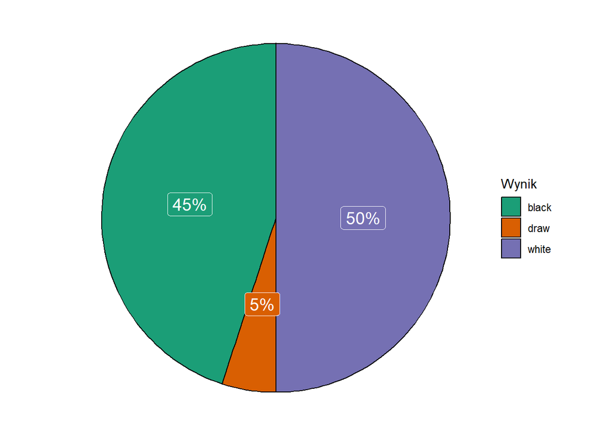

```r
vs <- as.data.frame(table(chess_clean$winner))
colnames(vs) <- c("status", "count")
vs <- vs |> mutate(percent = round(100 * (vs$count / sum(vs$count))))

ggplot(vs, aes(x = "", y = percent, fill = status)) +
  geom_col( color = "black") +
  geom_label(aes(label = paste0(percent, "%")),
             size = 5,
             color = "white",
             position = position_stack(vjust = 0.5),
             show.legend = FALSE) +
  guides(fill = guide_legend(title = "Wynik")) +
  coord_polar(theta = "y") +
  theme(legend.position = "bottom") +
  scale_fill_brewer(palette = "Dark2") +
  theme_void()
```

Z tego prostego wykresu kołowego możemy jasno wnioskować, że w analizowanych prawie 9 tys. partii białe mają stabilną przewagę nad czarnymi, a remisy są stosunkowo rzadkim zjawiskiem.

Teraz chcę przyjrzeć się dokładniej rozkładom rankingów graczy grających białymi i czarnymi, ponieważ zastanawiam się, *czy gracze po obu stronach mają porównywalny poziom rankingowy ?* i czy obserwowana przewaga białych nie wynika z tego, że oni grają ze słabszymi przeciwnikami.

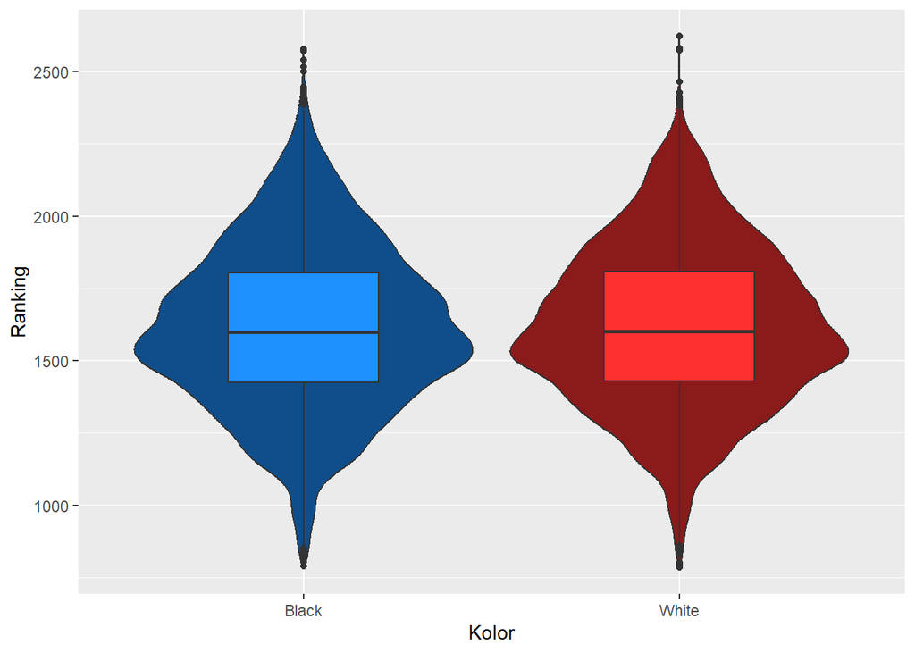

```r
ggplot() +
  geom_violin(
    data = chess_clean,
    aes(x = "Black", y = black_rating),
    fill = "dodgerblue4"
  ) +

  geom_boxplot(
    data = chess_clean,
    aes(x = "Black", y = black_rating),
    fill = "dodgerblue1",
    width = 0.4
  ) +
  labs(
    x = "Kolor",
    y = "Ranking"
  )+
  geom_violin(
    data = chess_clean,
    aes(x = "White", y = white_rating),
    fill = "firebrick4"
  ) +
  geom_boxplot(
    data = chess_clean,
    aes(x = "White", y = white_rating),
    fill = "firebrick1",
    width = 0.4

  ) +
  theme_grey()
```

Rozkłady rankingów graczy grających białymi i czarnymi są bardzo zbliżone. Mediany oraz zakresy międzykwartylowe niemal się pokrywają, co sugeruje brak istotnych różnic w poziomie umiejętności ze względu na kolor. Widoczna jest jednak delikatna przewaga białych w górnej części rozkładu.

#### Podział na grupy

W dalszej części chciałbym zbadać zachowania graczy na różnych poziomach rankingowych, dlatego potrzebne będzie podzielenie danych na odpowiednie grupy.

```r
breaks <- c(-Inf, 1200, 1400, 1600, 1800, 2000, 2200, 2300, 2400, 2500, 2700, Inf)

lvl <- c(
  "below 1200 (Novice)",
  "1200–1400 (Class D)",
  "1400–1600 (Class C)",
  "1600–1800 (Class B)",
  "1800–2000 (Class A)",
  "2000–2200 (Expert/CM)",
  "2200–2300 (CM/NM)",
  "2300–2400 (FM)",
  "2400–2500 (IM/GM)",
  "2500–2700 (GM)",
  "2700+ (WC contenders)"
)

clean_groups <- chess_clean |> mutate(
  game_rating = (white_rating + black_rating) / 2,
  rating_group = cut(game_rating, breaks, lvl, right = FALSE))
```

W celu analizy zachowań graczy na różnych poziomach umiejętności, dane zostały podzielone na grupy rankingowe. Podział ten oparto na powszechnie stosowanych klasyfikacjach spotykanych głównie w źródłach internetowych oraz w środowisku szachowym, które w przybliżony sposób opisują poziom gry zawodników na podstawie rankingu.

Przyjęto takie przedziały:

`Poniżej 1200 (Novice)` – gracze początkujący

`1200–1400 (Class D)` – gracze o podstawowych umiejętnościach

`1400–1600 (Class C)` – gracze średniozaawansowani

`1600–1800 (Class B)` – gracze solidni, dobrze opanowujący podstawy strategii i taktyki

`1800–2000 (Class A)` – gracze zaawansowani, grający stabilnie i świadomie

`2000–2200 (Expert / CM – Candidate Master)` – bardzo silni gracze, często posiadający lub aspirujący do tytułu kandydata na mistrza

`2200–2300 (CM / NM – Candidate Master / National Master)` – gracze mistrzowscy na poziomie krajowym

`2300–2400 (FM – FIDE Master)` – zawodnicy z oficjalnym tytułem mistrza federacji szachowej FIDE

`2400–2500 (IM / GM – International Master / Grandmaster)` – bardzo wysoki poziom międzynarodowy

`2500–2700 (GM – Grandmaster)` – światowa czołówka arcymistrzów

`Powyżej 2700 (WC contenders – World Championship contenders)` – absolutna elita światowa, potencjalni pretendenci do tytułu mistrza świata (takich w zestawie nie ma)

Skoro mamy już dane podzielone na grupy rankingowe, możemy zastanowić się, *jaki jest rozkład wyników partii w zależności od poziomu gry ?*, czy obserwowana przewaga białych utrzymuje się na wszystkich poziomach umiejętności.

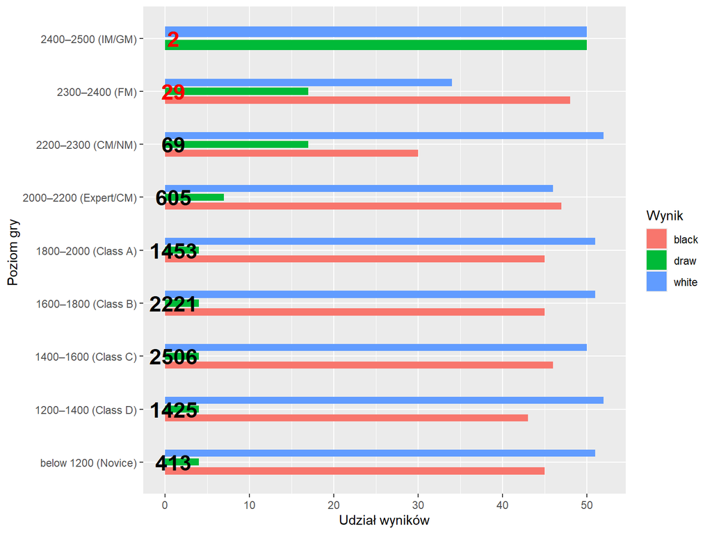

```r
groups3 <- clean_groups |>
  count(rating_group, winner) |>
  group_by(rating_group) |>
  mutate(percent = round(n / sum(n) * 100))

n_games <- clean_groups |> count(rating_group, name = "n_games")


ggplot(groups3, aes(x = rating_group, y = percent, fill = winner)) +
  geom_col(
    position = position_dodge(0.5),
    width = 0.4
  ) +
  coord_flip() +
  geom_text(
    data = n_games,
    aes(x = rating_group, y = 1, label = n_games),
    inherit.aes = FALSE,
    color = "black",
    fontface = "bold",
    size = 6
  )+
  geom_text(
    data = n_games |> filter(n_games < 50),
    aes(x = rating_group, y = 1, label = n_games),
    inherit.aes = FALSE,
    color = "red",
    fontface = "bold",
    size = 6
  )+
  labs(
    x = "Poziom gry ",
    y = "Udział wyników",
    fill = "Wynik"
  ) +
  theme_grey()
```

**Uwaga:** Ze względu na bardzo małą liczność obserwacji w najwyższych przedziałach rankingowych (FM oraz IM/GM), grupy te zostały wyłączone z dalszej analizy, aby uniknąć niestabilnych i trudnych do interpretacji wyników.

```r
groups_f <- clean_groups |>filter(!rating_group %in% c("2300–2400 (FM)","2400–2500 (IM/GM)"))
```

Teraz kontynuujemy analizę z wykorzystaniem grup rankingowych, ale nieco zmieniamy perspektywę i sprawdzimy, *jak zmienia się długość partii w zależności od poziomu rankingowego graczy oraz trybu gry ?*

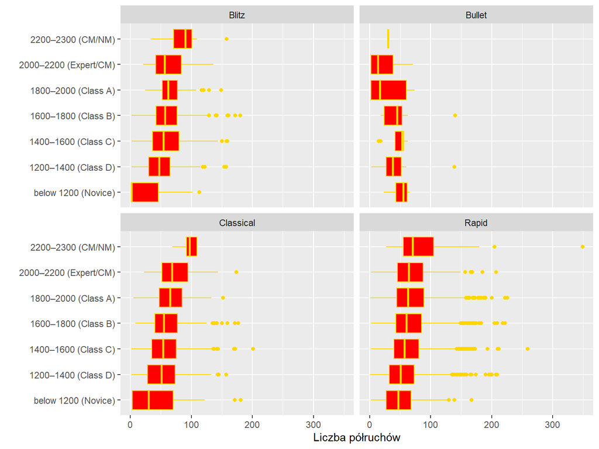

```r
groups_f4 <- groups_f |>
  separate(increment_code, into = c("base_time", "increment"), sep = "\\+",convert = TRUE) |>
  mutate(
    time_control = ifelse(base_time <= 2, "Bullet",
      ifelse(base_time <= 5, "Blitz",
        ifelse(base_time <= 15, "Rapid",
          "Classical"
        ))))

ggplot(groups_f4,aes(x = rating_group, y = turns)) +
  geom_boxplot(
    fill = "red",
    color = "gold"
  ) +
  coord_flip() +
  facet_wrap(~ time_control) +
  labs(x="", y = "Liczba półruchów") +
  theme_grey()
```

Według mojej analizy można stwierdzić, że długość partii silnie zależy od tempa gry, im wolniejsze tempo, tym dłuższe partie. Dodatkowo wraz ze wzrostem poziomu rankingowego gracze rozgrywają coraz dłuższe partie, co jest szczególnie widoczne w tempach Rapid i Classical.

Kolejnym pytaniem badawczym jest to, *jak poziom gry wpływa na najczęstsze sposoby zakończenia partii szachowej ?* Czy wraz ze wzrostem umiejętności graczy zmienia się charakter zakończeń partii, na przykład od szybkich matów i poddań na niższych poziomach do bardziej technicznych remisów i końcówek na poziomach wyższych?

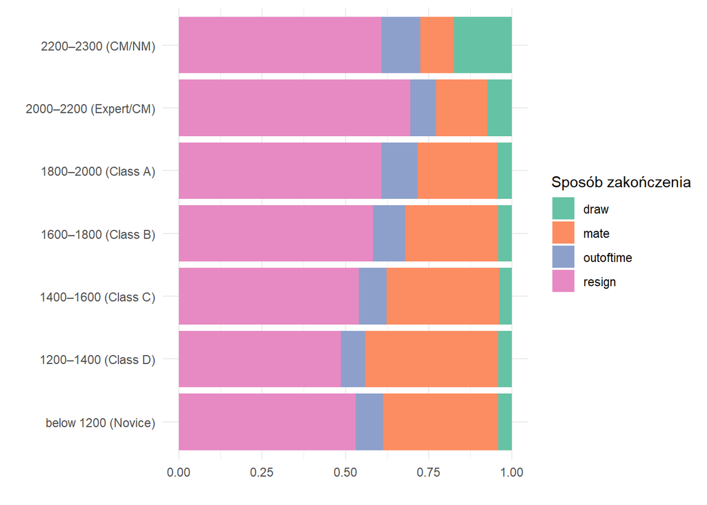

```r
groups_f5 <- groups_f4 |>
  count(rating_group, victory_status, name = "n") |>
  group_by(rating_group) |>
  mutate(percent = n / sum(n))

ggplot(groups_f5, aes(x = rating_group, y = percent, fill = victory_status)) +
  geom_col(position = "fill") +
  coord_flip() +
  scale_fill_brewer(palette = "Set2") +
  labs(x ="", y = "",fill = "Sposób zakończenia") +
  theme_minimal()
```

Wykres wyrażnei przedstawia, że na niższych poziomach dominują zakończenia matem(oprócz rezygnacji), na wyższych poziomach partie częściej kończą się poddaniem lub remisem, co świadczy o lepszym rozumieniu pozycji i większej precyzji gry. Podsumowując te wykres, można stwierdzić, że im silniejszy gracz, tym mniej wiaregodnym jest zakończenie partii matem i częściej dochodzi do poddań lub remisów. Ponadto zmiana struktury zakończeń partii wraz z poziomem gry potwierdza, że ranking dobrze odzwierciedla realne umiejętności graczy.

Na chwilę odkładamy grupy rankingowe i zobaczymy, *jak sposób zakończenia partii zależy od jej długości ?*

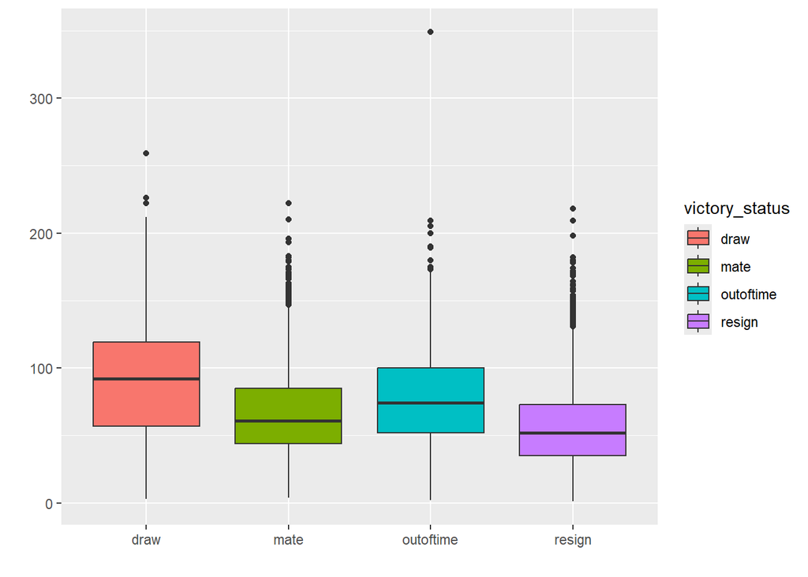

```r
ggplot(groups_f, aes(x = victory_status, y = turns, fill = victory_status)) +
  geom_boxplot() +
  labs(x="", y="")+
  theme_grey()
```

Możemy tu zauważyć, że partie zakończone poddaniem są zazwyczaj krótsze, co może wynikać z poważnych błędów (blunderów) popełnianych na wczesnym etapie gry, po których dalsza gra traci sens z perspektywy jednego z graczy. Z kolei partie zakończone remisem są najdłuższe, co sugeruje, że są to gry wyrównane, w których żadna ze stron nie jest w stanie uzyskać decydującej przewagi, a rozstrzygnięcie następuje dopiero w późnej fazie partii.

W dalszej części analizy zbadamy, *czy jest zależność pomiędzy trybem gry a rozkładem wyników partii szachowych?*

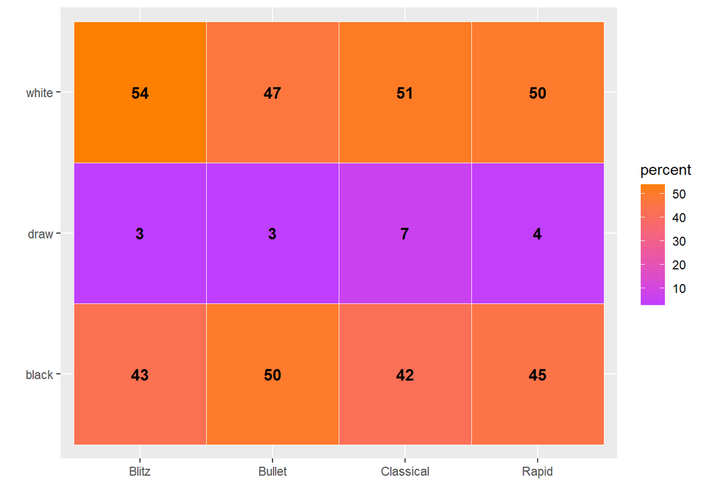

```r
groups_f7 <- groups_f4 |>
  count(time_control, winner, name = "n") |>
  group_by(time_control) |>
  mutate(percent = round(n / sum(n)*100))

n_tc <- groups_f4 |> count(time_control, name = "n_games")

ggplot(groups_f7, aes(x = time_control, y = winner, fill = percent)) +
  geom_tile(color = "white") +
  geom_text(aes(label =percent),
            fontface = "bold",
            size = 4) +
  labs(x="", y="")+
  scale_fill_gradient(
  low = "darkorchid1",
  high = "darkorange1")+
  theme_grey()
```

Można zaobserwować, że w trybie Bullet, czyli w rozgrywkach o najkrótszym limicie czasowym, białe tracą swoją typową przewagę, która w tym przypadku przechyla się na korzyść czarnych. Można to interpretować w ten sposób, że w tak szybkim tempie białe są zmuszone nadawać tempo gry i podejmować decyzje szybciej, co czyni je bardziej podatnymi na błędy oraz przekroczenie limitu czasu. Czarne natomiast mogą w większym stopniu reagować na ruchy przeciwnika, co w warunkach silnej presji czasu może stanowić istotną przewagę. Dodatkowo można zauważyć, że w szybkich trybach gry remisy występują znacznie rzadziej.

Na koniec analizy na chwile wrócimy do grup i sprawdzimy *czy wraz ze wzrostem poziomu rankingowego gracze rozgrywają dłuższą fazę debiutu ?*, co może sugerować korzystanie z bardziej złożonych i trudniejszych do zapamiętania wariantów debiutowych.

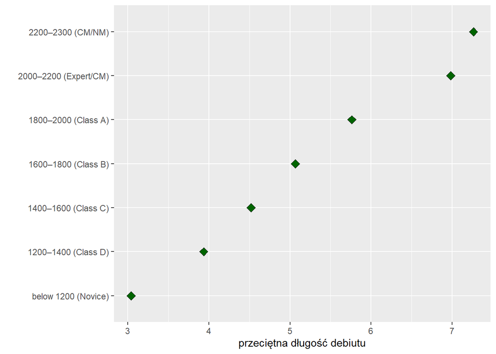

```r
groups_fl <- groups_f |> group_by(rating_group) |>
  summarise(mean_opening = mean(opening_ply),n = n())

ggplot(groups_fl, aes(x =mean_opening, y = rating_group)) +
   geom_point(
    shape = 23,
    size = 3,
    fill = "darkgreen"
  ) +
  labs(x = "przeciętna długość debiutu", y = "")
```

Tu jasno widać, że wraz ze wzrostem poziomu gry gracze częściej pozostają dłużej w fazie debiutu, co potwierdza hipotezę i wskazuje, że podział na grupy rankingowe sensownei odzwierciedla poziom umiejętności gracza.

#### Krótkie podsumowanie

Cała analiza była dla mnie okazją, by z ciekawości przyjrzeć się danym szachowym i sprawdzić, które intuicyjne przekonania rzeczywiście znajdują potwierdzenie w danych, a które okazały się mitami.